1. Write two functions [rew,draws]=UCB1(T,MAB,...), [rew,draws]=TS(T,MAB,...) simulating a bandit game of length T with the UCB1 and Thompson Sampling strategy on the bandit model MAB: rew and draws are the sequence of the T rewards obtained and of the T the arms drawn.

```python
import numpy as np
import arms
import matplotlib.pyplot as plt
from math import log
from tqdm import tqdm

# Build your own bandit problem

random_state = np.random.randint(1, 400000)

# this is an example, please change the parameters or arms!
arm1 = arms.ArmBernoulli(0.8, random_state=random_state)
arm2 = arms.ArmBernoulli(0.9, random_state=random_state)
arm3 = arms.ArmBernoulli(0.25, random_state=random_state)
arm4 = arms.ArmBernoulli(0.5, random_state=random_state)


MAB = [arm1, arm2, arm3, arm4]

# bandit : set of arms

nb_arms = len(MAB)
means = [el.mean for el in MAB]

# Display the means of your bandit (to find the best)
print('means: {}'.format(means))
mu_max = np.max(means)

# Comparison of the regret on one run of the bandit algorithm
# try to run this multiple times, you should observe different results



def UCB1(T,MAB,alpha):
    rew=[]
    draws=[]
    N=np.array([0]*len(MAB))
    S=[0]*len(MAB)
    k=0
    while(k<len(MAB)):
        r=MAB[k].sample()[0]
        draws.append(k)
        rew.append(r)
        S[k]+=float(r)
        N[k]+=1
        k+=1
    score=S/N+alpha*np.sqrt(log(k-1)/2*N)
    for p in range(k,T):
        a=np.argmax(score)
        r=MAB[a].sample()[0]
        draws.append(a)
        rew.append(r)
        S[a]+=float(r)
        N[a]+=1
        score=S/N+alpha*np.sqrt(log(p)/2*N)
    return [rew,draws]

def TS(T,MAB):
    rew=[]
    draws=[]
    N=np.array([0]*len(MAB))
    S=[0]*len(MAB)
    for k in range(T):
        A=[np.random.beta(S[a]+1,N[a]-S[a]+1) for a in range(len(MAB))]
        a=np.argmax(A)
        r=MAB[a].sample()[0]
        draws.append(a)
        rew.append(r)
        N[a]+=1
        S[a]+=r
    return [rew,draws]

def Naive(T,MAB):
    rew=[]
    draws=[]
    N=np.array([0]*len(MAB))
    S=[0]*len(MAB)
    k=0
    while(k<len(MAB)):
        r=MAB[k].sample()[0]
        draws.append(k)
        rew.append(r)
        S[k]+=float(r)
        N[k]+=1
        k+=1
    score=S/N
    for p in range(k,T):
        a=np.argmax(score)
        r=MAB[a].sample()[0]
        draws.append(a)
        rew.append(r)
        S[a]+=float(r)
        N[a]+=1
        score=S/N
    return [rew,draws]
```

```
means: [0.8, 0.9, 0.25, 0.5]
```

2. Based on many simulations, estimate the expected regret of UCB1 and Thompson Sampling and display regret curves. You may also add the naive strategy that selects the empirical best arm at each round.

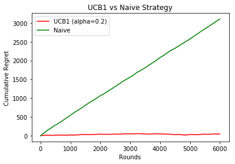

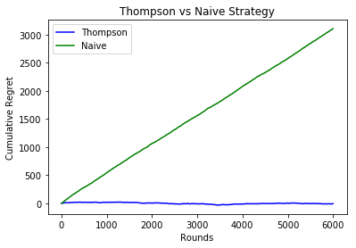

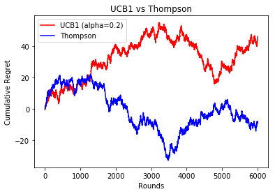

```python
random_state = np.random.randint(1, 400000)
T = 6000  # horizon
# My example
arm1 = arms.ArmBernoulli(0.8, random_state=random_state)
arm2 = arms.ArmBernoulli(0.3, random_state=random_state)
arm3 = arms.ArmBernoulli(0.25, random_state=random_state)
arm4 = arms.ArmBernoulli(0.5, random_state=random_state)

# bandit : set of arms
MAB = [arm1, arm2, arm3, arm4]



nb_arms = len(MAB)
means = [el.mean for el in MAB]
mu_max = np.max(means)

#Cumulative expected regret UCB1, Thompson Sampling and Naive strategy
[rew1,draws1]=UCB1(T, MAB,0.2)
reg1 = mu_max * np.arange(1, T + 1) - np.cumsum(rew1)
[rew2,draws2]=TS(T, MAB)
reg2 = mu_max * np.arange(1, T + 1) - np.cumsum(rew2)
[rew3,draws3]=Naive(T,MAB)
reg3 = mu_max * np.arange(1, T + 1) - np.cumsum(rew3)


#Different comparisons
plt.figure(1)
x = np.arange(1, T+1)
plt.plot(x, reg1,c='r', label='UCB1 (alpha=0.2)')
plt.plot(x, reg3,c='g', label='Naive')
plt.xlabel('Rounds')
plt.ylabel('Cumulative Regret')
plt.title('UCB1 vs Naive Strategy')
plt.legend()
plt.show()

plt.figure(2)
x = np.arange(1, T+1)
plt.plot(x, reg2, c='blue', label='Thompson')
plt.plot(x, reg3, c='g', label='Naive')
plt.xlabel('Rounds')
plt.ylabel('Cumulative Regret')
plt.title('Thompson vs Naive Strategy')
plt.legend()
plt.show()

plt.figure(3)
x = np.arange(1, T+1)
plt.plot(x, reg1,c='r', label='UCB1 (alpha=0.2)')
plt.plot(x, reg2,c='blue', label='Thompson')
plt.xlabel('Rounds')
plt.ylabel('Cumulative Regret')
plt.title('UCB1 vs Thompson')
plt.legend()
plt.show()
```

We can notice that the Naive method has a cumulative regret that goes to infinity when the number of Rounds increases while the other two approaches (UCB1 and Thompson) fluctuate close to zero.

3. Add the “oracle” regret curve t → C(p) log(t) on your graph.

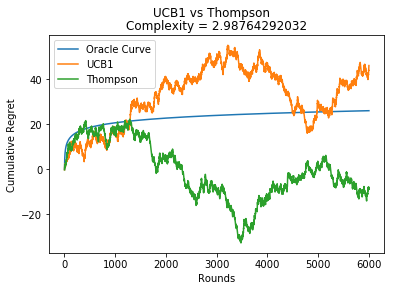

```python
kl = lambda x,y: x*log(x/y)+(1-x)*log((1-x)/(1-y))

def complexity(p):
    C=0
    p_opt,i_opt=np.max(p),np.argmax(p)
    for i in range(len(MAB)):
        if (i!=i_opt):
            C+=(p_opt-p[i])/kl(p[i],p_opt)
    return C

p = means
C=complexity(p)

plt.figure(3)
x = np.arange(1, T+1)
plt.plot(x,C*np.log(x), label='Oracle Curve')
plt.plot(x, reg1, label='UCB1')
plt.plot(x, reg2, label='Thompson')
plt.xlabel('Rounds')
plt.ylabel('Cumulative Regret')
plt.suptitle('UCB1 vs Thompson')
plt.title('Complexity = '+str(C))
plt.legend()
plt.show()
```

We can see that the Thompson regret curve stays below the Oracle Curve for the bernoulli arms with complexity= 2.98.

Q1: For two different Bernoulli bandit problems (that you specify), with different complexity, compare the regret of Thompson Sampling with that of UCB1. Add Lai and Robbins’ lower bound on your plots.

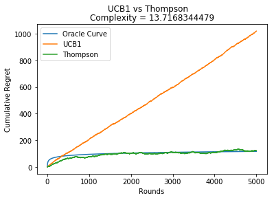

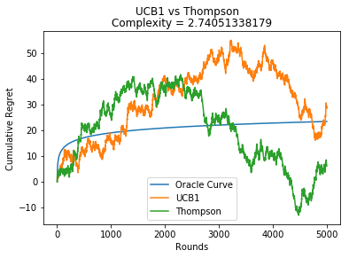

```python
#Bernoulli bandit problem 1
arm1 = arms.ArmBernoulli(0.1, random_state=random_state)
arm2 = arms.ArmBernoulli(0.3, random_state=random_state)
arm3 = arms.ArmBernoulli(0.25, random_state=random_state)
arm4 = arms.ArmBernoulli(0.2, random_state=random_state)
#Bernoulli bandit problem 2
arm5 = arms.ArmBernoulli(0.8, random_state=random_state)
arm6 = arms.ArmBernoulli(0.5, random_state=random_state)
arm7 = arms.ArmBernoulli(0.25, random_state=random_state)
arm8 = arms.ArmBernoulli(0.1, random_state=random_state)
MAB1 = [arm1, arm2, arm3, arm4]
MAB2 = [arm5, arm6, arm7, arm8]
nb_arms = len(MAB)
p1,p2 = [el.mean for el in MAB1],[el.mean for el in MAB2]
mu_max1, mu_max2 = np.max(p1), np.max(p2)
C1,C2 = complexity(p1), complexity(p2)
T=5000
#Cumulative expected regret UCB1, Thompson Sampling and Naive strategy
[rew1,draws1]=UCB1(T, MAB1,alpha=0.2)
reg1 = mu_max1 * np.arange(1, T + 1) - np.cumsum(rew1)
[rew2,draws2]=TS(T, MAB1)
reg2 = mu_max1 * np.arange(1, T + 1) - np.cumsum(rew2)


plt.figure(1)
x = np.arange(1, T+1)
plt.plot(x,C1*np.log(x), label='Oracle Curve')
plt.plot(x, reg1, label='UCB1')
plt.plot(x, reg2, label='Thompson')
plt.xlabel('Rounds')
plt.ylabel('Cumulative Regret')
plt.suptitle('UCB1 vs Thompson')
plt.title('Complexity = '+str(C1))
plt.legend()
plt.show()

#Cumulative expected regret UCB1, Thompson Sampling and Naive strategy
[rew3,draws3]=UCB1(T, MAB2,alpha=0.2)
reg3 = mu_max2 * np.arange(1, T + 1) - np.cumsum(rew3)
[rew4,draws4]=TS(T, MAB2)
reg4 = mu_max2 * np.arange(1, T + 1) - np.cumsum(rew4)
plt.figure(2)
x = np.arange(1, T+1)
plt.plot(x,C2*np.log(x), label='Oracle Curve')
plt.plot(x, reg3, label='UCB1')
plt.plot(x, reg4, label='Thompson')
plt.xlabel('Rounds')
plt.ylabel('Cumulative Regret')
plt.autoscale(enable=True, axis='both', tight=None)
plt.suptitle('UCB1 vs Thompson')
plt.title('Complexity = '+str(C2))
plt.legend()
plt.show()
```

We can see that for a high complexity (C=13.71) the UCB1 regret diverges to infinity when the number of Rounds increases while the Thompson regret curve stay below the Oracle Curve when T become large as predict by theory

For low complexity, we can see that the Thompson and UCB1 regret curves have approximatly the same variations and fluctuate close to 0 while Thompson curve stays below the Oracle Curve when T become large.

We can then conclude that for high complexity the Thompson Sampling is performing better than the UCB1

. Using the other classes of arms, build a MAB with arms that are not only Bernoulli. Why non-parametric? because we consider a MAB with different classes of arms (which can even be non parametric).

```
means: [0.54, 0.3, 0.23134263963622598, 0.495]
```

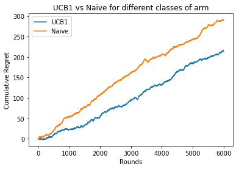

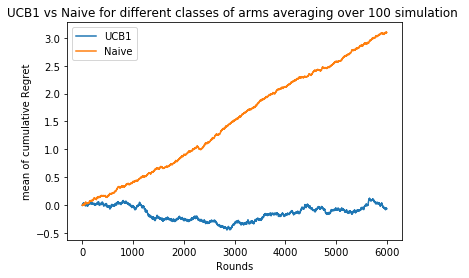

```python
arm1 = arms.ArmBernoulli(0.54, random_state=random_state)
arm2 = arms.ArmBeta(3,7, random_state=random_state)
arm3 = arms.ArmExp(4, random_state=random_state)
arm4 = arms.ArmFinite(np.array([0.1,0.2,0.5,0.85]),np.array([0.2,0.1,0.4,0.3]), random_state=random_state)

T=6000
# bandit : set of arms
MAB = [arm1, arm2, arm3, arm4]

nb_arms = len(MAB)
means = [el.mean for el in MAB]
mu_max = np.max(means)
print('means: {}'.format(means))

#Cumulative expected regret UCB1, Thompson Sampling and Naive strategy for only 1 simulation
[rew1,draws1]=UCB1(T, MAB, alpha=0.2)
reg1 = mu_max * np.arange(1, T + 1) - np.cumsum(rew1)
[rew2,draws2]=Naive(T,MAB)
reg2 = mu_max * np.arange(1, T + 1) - np.cumsum(rew2)

plt.figure(1)
x = np.arange(1, T+1)
plt.plot(x, reg1, label='UCB1')
plt.plot(x, reg2, label='Naive')
plt.xlabel('Rounds')
plt.ylabel('Cumulative Regret')
plt.title('UCB1 vs Naive for different classes of arm')
plt.legend()
plt.show()
#Mean cumulative expected regret UCB1, and Naive strategy for 100 simulations

nb_simu=100
dic={'UCB1': lambda T,MAB: UCB1(T,MAB,alpha=0.2),\
     'Naive': lambda T,MAB: Naive(T,MAB)}
for key,value in dic.items():
    i=0
    for k in tqdm(range(nb_simu), desc="Simulating {}".format(key)):
        regret = np.zeros((nb_simu, T))
        norm_dist = np.zeros((nb_simu, T))
        [rew,draws] =value(T,MAB)
        regret[k, :] = mu_max * np.arange(1, T + 1) - np.cumsum(rew)
            # compute average (over sim) of the algorithm performance and plot it
    mean_regret = np.mean(regret,axis=0)
    plt.figure(2)
    plt.plot(mean_regret, label=key)
    plt.ylabel('mean of cumulative Regret')
    plt.xlabel('Rounds')
    plt.title('UCB1 vs Naive for different classes of arms averaging over 100 simulation ')
    plt.legend()
plt.show()
```

We can see that the cumulative regret of the UCB1 method still below the one of the Naive approach when the arms aren't drawn from the same law.

We can conclude then that the UCB1 method is performing better than the Naive one

2. Propose an adaptation of Thompson Sampling to handle non-binary rewards and implement it together with UCB1 on your bandit model (see e.g., [Agrawal and Goyal, 2012]).

```python
arm1 = arms.ArmBernoulli(0.54, random_state=random_state)
arm2 = arms.ArmBeta(3,7, random_state=random_state)
arm3 = arms.ArmExp(4, random_state=random_state)
arm4 = arms.ArmFinite(np.array([0.1,0.2,0.5,0.85]),np.array([0.2,0.1,0.4,0.3]), random_state=random_state)

T=6000
# bandit : set of arms
MAB = [arm1, arm2, arm3, arm4]

nb_arms = len(MAB)
mu_max = np.max(means)
```

```python
def simulateRV(probabilities,values,n):
    bins = np.add.accumulate(probabilities)
    return values[np.digitize(np.random.rand(n),bins)]
```

```python
def non_binar_TS(T,MAB):
    rew=[]
    draws=[]
    N=np.array([0]*len(MAB))
    S=[0]*len(MAB)
    for k in range(T):
        A=[np.random.beta(S[a]+1,N[a]-S[a]+1) for a in range(len(MAB))]
        a=np.argmax(A)
        sample=MAB[a].sample()[0]
        proba=np.array([1-sample,sample])
        values=np.array([0,1])
        r=simulateRV(proba,values,1)
        draws.append(a)
        rew.append(r)
        N[a]+=1
        S[a]+=r
    return [rew,draws]
```

Q2: Describe the proposed implementation of Thompson Sampling and present a regret curve in a bandit model that you specify. Does the notion of complexity still make sense? Suggestion: [Burnetas and Katehakis, 1996].

To adapt the Thompson method to a non-binary reward, for the reward r_t which is a float in [0,1] we simulate a bernoulli sample of parameter r_t as a binary reward for each trial.

The Burnetas and Katehakis have extended the regret lower bound to non binary problems with a adapted complexity which has the form C(p) = $\frac{1}{D_k(\theta)}$ where $D_k(\theta)=\inf_{vk^*\in \Theta_k: E(νk)>p^*}\text{KL}(vk,vk^*)$ where $\theta$ = (ν1,ν2,ν3,ν4), where each νk (k ∈ {1,··· ,4}) is a real-valued measure that represents the distribution reward of arm k and where KL is the Kullback-Leibler divergence and $\Theta_k$ is the set of possible reward distributions of arm k.

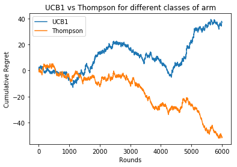

```python
[rew1,draws1]=UCB1(T, MAB, alpha=0.2)
reg1 = mu_max * np.arange(1, T + 1) - np.cumsum(rew1)
[rew3,draws3]=non_binar_TS(T,MAB)
reg3 = mu_max * np.arange(1, T + 1) - np.cumsum(rew3)

plt.figure(1)
x = np.arange(1, T+1)
plt.plot(x, reg1, label='UCB1')
plt.plot(x, reg3, label='Thompson')
plt.xlabel('Rounds')
plt.ylabel('Cumulative Regret')
plt.title('UCB1 vs Thompson for different classes of arm')
plt.legend()
plt.show()
```

We could say the same remaks as in the bernoulli case when extending the Thompson sampling method to non_binary rewards

Q3: Implement the LinUCB algorithm for the provided MovieLens problem. Compare the performance against the following algorithms (consider a horizon T = 6000)

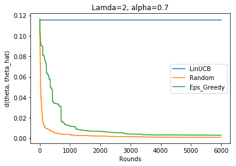

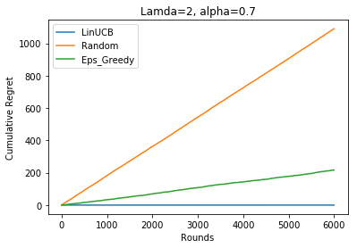

```python
import numpy as np
from linearmab_models import ToyLinearModel, ColdStartMovieLensModel
import matplotlib.pyplot as plt
from tqdm import tqdm

random_state = np.random.randint(0, 24532523)
model2 = ToyLinearModel(n_features=8,n_actions=20,#    random_state=random_state,
                       noise=0.1)

model = ColdStartMovieLensModel(random_state=random_state,noise=0.1)

n_a = model.n_actions
d = model.n_features

T = 6000


##################################################################
def linUCB(Z,y,lamda,alpha):
    features=model.features
    A=np.linalg.inv(np.dot(np.array(Z).T,Z)+lamda*np.eye(d))
    if (len(Z)==0):
        theta=[0]*d
    else:
        theta=np.dot(np.dot(A,np.array(Z).T),y)
    beta=alpha*np.sqrt([np.dot(np.dot(phi,A),phi.T) for phi in features])
    B=np.array([float(np.dot(features[i].T,theta)+beta[i]) for i in range(len(beta))])
    action=np.argmax(B)
    return [action,theta]

def Random(Z,y,lamda):
    a_t=np.random.randint(n_a)
    A=np.linalg.inv(np.dot(np.array(Z).T,Z)+lamda*np.eye(d))
    if (len(Z)==0):
        theta=[0]*d
    else:
        theta=np.dot(np.dot(A,np.array(Z).T),y)
    return [a_t,theta]


def Eps_Greedy(Z,y,lamda,epsilon=0.2):
    A=np.linalg.inv(np.dot(np.array(Z).T,Z)+lamda*np.eye(d))
    if (len(Z)==0):
        theta=[0]*d
    else:
        theta=np.dot(np.dot(A,np.array(Z).T),y)
    R=[]
    for i in range(n_a):
        R.append(model.reward(i))
    i_max=np.argmax(R)
    a=np.random.random()
    if (a<epsilon):
        a_t=np.random.randint(0,n_a)
    else:
        a_t=i_max
    return [a_t,theta]
##################################################################

nb_simu = 50

dic={'LinUCB': lambda Z,y: linUCB(Z,y,2,0.7),'Random':lambda Z,y: Random(Z,y,2),'Eps_Greedy':\
     lambda Z,y: Eps_Greedy(Z,y,2)}
for key,value in dic.items():
    i=0
    for k in tqdm(range(nb_simu), desc="Simulating {}".format(key)):
        Z=[]
        y=[]
        regret = np.zeros((nb_simu, T))
        norm_dist = np.zeros((nb_simu, T))
        for t in range(T):
            [a_t,theta_hat]=value(Z,y) # algorithm picks the action
            r_t = model.reward(a_t) # get the reward
            Z.append(model.features[a_t])
            y+=[r_t]

            # store regret
            regret[k, t] = model.best_arm_reward() - r_t
            norm_dist[k, t] = np.linalg.norm([theta_hat[i]-model.real_theta[i] for i in range(len(theta_hat))])

            # compute average (over sim) of the algorithm performance and plot it
    mean_norms = np.mean(norm_dist,axis=0)
    mean_regret = np.mean(regret,axis=0)
    plt.figure(1)
    plt.plot(mean_norms, label=key)
    plt.ylabel('d(theta, theta_hat)')
    plt.xlabel('Rounds')
    plt.title('Lamda=2, alpha=0.7')
    plt.legend()

    plt.figure(2)
    plt.plot(mean_regret.cumsum(), label=key)
    plt.ylabel('Cumulative Regret')
    plt.xlabel('Rounds')
    plt.title('Lamda=2, alpha=0.7')
    plt.legend()
plt.show()
```

For small value of alpha (0.7) and for lambda=2, I have averaged the results over 50 simulation with a horizon of 6000 iterations. We notice that even if the cumulative Regret curve of the LinUCB is better than those of epsilon-greedy and random methods, the estimated theta doesn't converge to the true one as like the two other approaches. We can notice also that the estimated theta of the LinUCB method converges rapidly to it's limit (after 50 iterations) comparing to the theta of the random method which converges secondly (after 2000 iterations) and the eps-greedy method which converges lastly (after 3500 iterations). Also the estimated theta of the random method converges exactly to the true theta while the one of epsilon greedy converges approximatly to it, but the random method has a cumulative Regret that increases rapidly with the number of Rounds comparing to the epsilon greedy one.

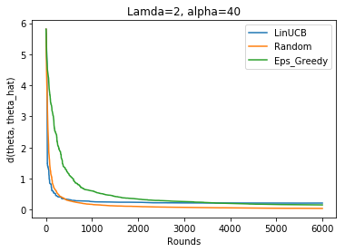

[figure not shown]

```python
nb_simu = 50

dic={'LinUCB': lambda Z,y: linUCB(Z,y,2,40),'Random':lambda Z,y: Random(Z,y,2,0.7),'Eps_Greedy':\
     lambda Z,y: Eps_Greedy(Z,y,2,0.7)}
for key,value in dic.items():
    i=0
    regret = np.zeros((3,nb_simu, T))
    norm_dist = np.zeros((3,nb_simu, T))
    for k in tqdm(range(nb_simu), desc="Simulating {}".format(key)):
        Z=[]
        y=[]

        for t in range(T):
            [a_t,theta_hat]=value(Z,y) # algorithm picks the action
            r_t = model.reward(a_t) # get the reward
            Z.append(model.features[a_t])
            y+=[r_t]

            # store regret
            regret[i,k, t] = model.best_arm_reward() - r_t
            norm_dist[i,k, t] = np.linalg.norm([theta_hat[i]-model.real_theta[i] for i in range(len(theta_hat))])
    i+=1
            # compute average (over sim) of the algorithm performance and plot it
    mean_norms = np.mean(norm_dist[0],axis=0)
    mean_regret = np.mean(regret[0],axis=0)
    plt.figure(1)
    plt.plot(mean_norms, label=key)
    plt.ylabel('d(theta, theta_hat)')
    plt.title('Lamda=2, alpha=40')
    plt.xlabel('Rounds')
    plt.legend()

    plt.figure(2)
    plt.plot(mean_regret.cumsum(), label=key)
    plt.ylabel('Cumulative Regret')
    plt.title('Lamda=2, alpha=40')
    plt.xlabel('Rounds')
    plt.legend()
plt.show()
```

For large values of alpha (40) with the same lambda (2), we can notice this time that the estimated theta of the LinUCB method has converged to the true one as well as the other two methods. Also we can notice with the linUCB method, the convergence is so fast (around 30 iterations), while the epsilon greedy is the last one to have its estimated theta converges to the true one (after 3000 iterations)

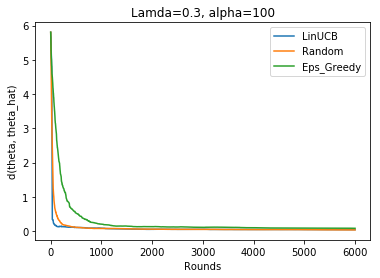

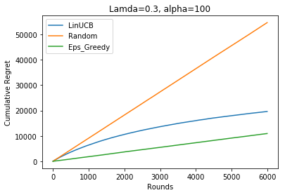

```python
##################################################################
T=6000
nb_simu = 20

dic={'LinUCB': lambda Z,y: linUCB(Z,y,0.3,100),'Random':lambda Z,y: Random(Z,y,0.3),'Eps_Greedy':\
     lambda Z,y: Eps_Greedy(Z,y,0.3)}
for key,value in dic.items():
    i=0
    regret = np.zeros((3,nb_simu, T))
    norm_dist = np.zeros((3,nb_simu, T))
    for k in tqdm(range(nb_simu), desc="Simulating {}".format(key)):
        Z=[]
        y=[]

        for t in range(T):
            [a_t,theta_hat]=value(Z,y) # algorithm picks the action
            r_t = model.reward(a_t) # get the reward
            Z.append(model.features[a_t])
            y+=[r_t]

            # store regret
            regret[i,k, t] = model.best_arm_reward() - r_t
            norm_dist[i,k, t] = np.linalg.norm([theta_hat[i]-model.real_theta[i] for i in range(len(theta_hat))])
    i+=1
            # compute average (over sim) of the algorithm performance and plot it
    mean_norms = np.mean(norm_dist[0],axis=0)
    mean_regret = np.mean(regret[0],axis=0)
    plt.figure(1)
    plt.plot(mean_norms, label=key)
    plt.ylabel('d(theta, theta_hat)')
    plt.title('Lamda=0.3, alpha=100')
    plt.xlabel('Rounds')
    plt.legend()

    plt.figure(2)
    plt.plot(mean_regret.cumsum(), label=key)
    plt.ylabel('Cumulative Regret')
    plt.title('Lamda=0.3, alpha=100')
    plt.xlabel('Rounds')
    plt.legend()
plt.show()
```